# What Effect The Duration In The GoBike System?

## by Aya Tarek

## Investigation Overview

> In this Investigation we aim to check the features in the GoBike system dataset and discover the features that effect the duration of a bike trip.

## Dataset Overview

> There are 183412 GoBike trip in the dataset with 16 features to describe the trip like the Duration of the trip, some information about the start station and the end station, some information about the Users and the type of the Users.

## Distribution of the Trip Duration in Ford GoBike System

> The distribution is skewed to the right (positively skewed), Indicates that the majority of the trips are less than 20 minutes long.

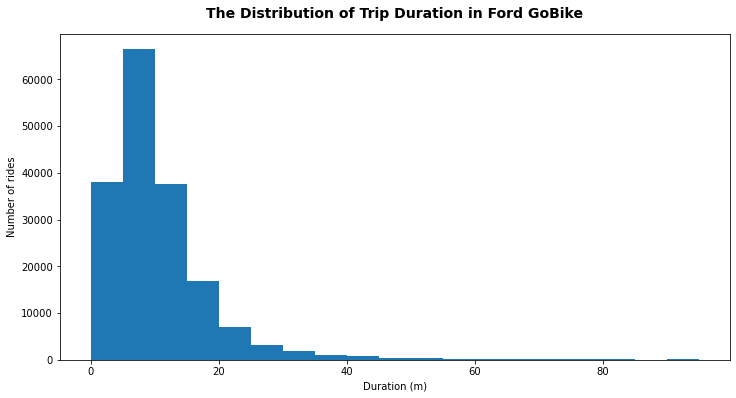

## The Distribution of User Types in Ford GoBike Users

> The majority of the Users are subscribers, at 91%

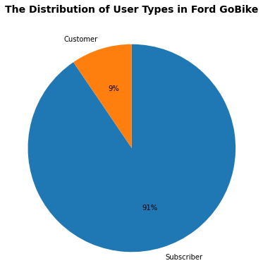

## The Relation between The Distance and The Duration

> There is no specific relation found between the Distance and the Duration. But it obvious that most of the rides with 1km distance takes about 10m duration.

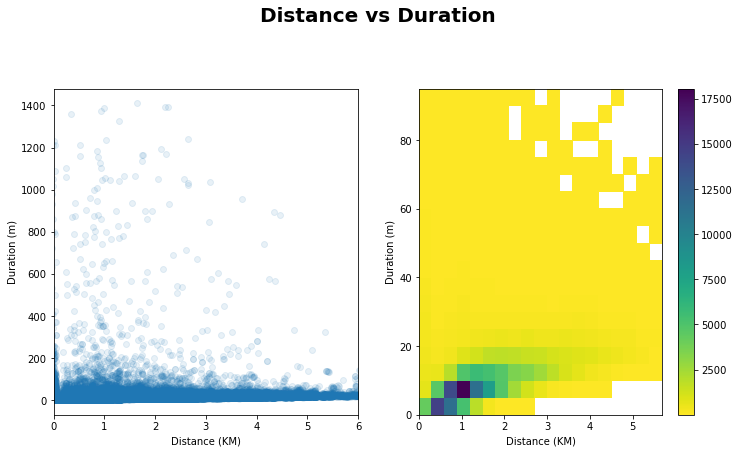

> There is no observed relation between the distance and duration shown in the scatter plot, But the heat maps shows that the most of the rides with 1km distance takes about 10m duration.

## Average Trip Duration per User Group

> It was very interset to discovre that customers spends more duration than the subscribers. But if you think of it the customers don't usually going on bike trips as a result they spend more time, unlike the subscribers who going on bike trips more often, it seems more sense. However, it was surprising to see that customers, on average, take longer duration than subscribers

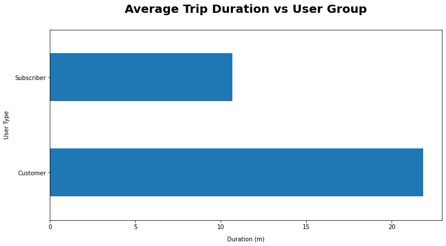

## The Relation between Distance and Duration per User group

> The Majority of the users are Subscribers with positive relationship between the Distance and the Duration

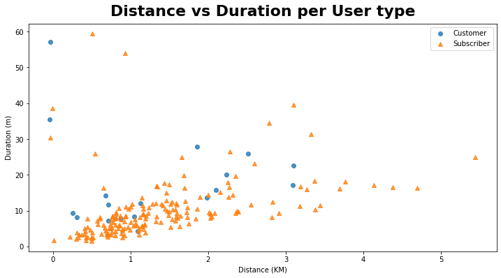